# Water Intake and Diabetes in US Adults: NHANES 2021-2023

# Data Preparation

```r
data <- read_excel("final_data.xlsx")

df <- data %>%
  # Filter out Race categories with 0 obser
  filter(!Race %in% c(6, 7)) %>%
  mutate(
    #Continuous variables as numeric
    Age = as.numeric(Age),
    BMI = as.numeric(BMI),
    Income_PIR = as.numeric(Income_PIR),
    Energy_kcal = as.numeric(Energy_kcal),
    Sugar_g = as.numeric(Sugar_g),
    Water_g = as.numeric(Water_g),
    HbA1c = as.numeric(HbA1c),

    #Categorical variables as factors
    Gender = factor(Gender, levels = c(0, 1),
                   labels = c("Female", "Male")),

    # Only keep Race categories (1,2,3,4)
    Race = factor(Race, levels = c(1, 2, 3, 4),
                 labels = c("Mexican American", "Other Hispanic",
                           "Non-Hispanic White", "Non-Hispanic Black")),

    Education = factor(Education, levels = c(1, 2, 3, 4, 5),
                      labels = c("< 9th grade", "9-11th grade",
                                "High school/GED", "Some college",
                                "College grad+")),

    Smoking = factor(Smoking, levels = c(0, 1),
                    labels = c("No", "Yes")),

    Diabetes = factor(Diabetes, levels = c(0, 1),
                     labels = c("No", "Yes")),

    #Create water quartiles
    Water_Q = cut(Water_g,
                  breaks = quantile(Water_g, probs = seq(0, 1, 0.25)),
                  labels = c("Q1", "Q2", "Q3", "Q4"),
                  include.lowest = TRUE)
  )

#Set Q1 reference group
df$Water_Q <- relevel(df$Water_Q, ref = "Q1")

#Create numeric version for trend test
df$Water_Q_numeric <- as.numeric(df$Water_Q)
```

# Table 1: Baseline Characteristics by Diabetes Status

```r
tab1 <- CreateTableOne(
  vars = c("Age", "Gender", "Race", "Education", "BMI", "Income_PIR",
           "Smoking", "Energy_kcal", "Sugar_g", "Water_g", "HbA1c"),
  strata = "Diabetes",
  data = df,
  factorVars = c("Gender", "Race", "Education", "Smoking"),
  test = FALSE
)

#Get table output (median/IQR for continuous)
tab1_print <- print(tab1,
                   nonnormal = c("Age", "BMI", "Income_PIR", "Energy_kcal",
                                "Sugar_g", "Water_g", "HbA1c"),
                   showAllLevels = TRUE,
                   printToggle = FALSE)

# Calculate p-values
# Continuous: Wilcoxon test
# Categorical: Chi-square test
p_vals <- c(
  wilcox.test(Age ~ Diabetes, data = df)$p.value,
  wilcox.test(BMI ~ Diabetes, data = df)$p.value,
  wilcox.test(Income_PIR ~ Diabetes, data = df)$p.value,
  wilcox.test(Energy_kcal ~ Diabetes, data = df)$p.value,
  wilcox.test(Sugar_g ~ Diabetes, data = df)$p.value,
  wilcox.test(Water_g ~ Diabetes, data = df)$p.value,
  wilcox.test(HbA1c ~ Diabetes, data = df)$p.value,
  chisq.test(table(df$Gender, df$Diabetes))$p.value,
  chisq.test(table(df$Race, df$Diabetes))$p.value,
  chisq.test(table(df$Education, df$Diabetes))$p.value,
  chisq.test(table(df$Smoking, df$Diabetes))$p.value
)

#Format p-values
format_p <- function(p) {
  if(is.na(p)) return("NA")
  if(p < 0.001) return("<0.001")
  return(sprintf("%.3f", p))
}

p_fmt <- sapply(p_vals, format_p)


tab1_df <- as.data.frame(tab1_print)
tab1_df$P <- ""
var_names <- c("Age", "BMI", "Income_PIR", "Energy_kcal", "Sugar_g",
               "Water_g", "HbA1c", "Gender", "Race", "Education", "Smoking")
for(i in 1:length(var_names)) {
  rows <- grep(var_names[i], rownames(tab1_df))
  if(length(rows) > 0) tab1_df$P[rows[1]] <- p_fmt[i]
}

# Show
kable(tab1_df, caption = "Table 1: Baseline Characteristics by Diabetes Status") %>%
  kable_styling(bootstrap_options = c("striped", "hover")) %>%
  footnote(general = c("Continuous variables: Median (IQR), Wilcoxon rank-sum test",
                      "Categorical variables: n (%), Chi-square test"))
```

Table 1: Baseline Characteristics by Diabetes Status

|  | level | No | Yes | P |
| --- | --- | --- | --- | --- |
| n |  | 3327 | 558 |  |
| Age..median..IQR.. |  | 57.00 [39.00, 67.00] | 64.00 [57.00, 71.00] | <0.001 |
| Gender…. | Female | 1894 (56.9) | 282 (50.5) | 0.006 |
| X | Male | 1433 (43.1) | 276 (49.5) |  |
| Race…. | Mexican American | 193 ( 6.5) | 46 ( 9.2) | <0.001 |
| X.1 | Other Hispanic | 300 (10.1) | 64 (12.9) |  |
| X.2 | Non-Hispanic White | 2159 (72.5) | 304 (61.0) |  |
| X.3 | Non-Hispanic Black | 327 (11.0) | 84 (16.9) |  |
| Education…. | < 9th grade | 90 ( 2.7) | 39 ( 7.0) | <0.001 |
| X.4 | 9-11th grade | 178 ( 5.4) | 77 (13.8) |  |
| X.5 | High school/GED | 617 (18.5) | 138 (24.7) |  |
| X.6 | Some college | 1006 (30.2) | 183 (32.8) |  |
| X.7 | College grad+ | 1436 (43.2) | 121 (21.7) |  |
| BMI..median..IQR.. |  | 28.00 [24.40, 32.70] | 32.60 [27.90, 37.35] | <0.001 |
| Income_PIR..median..IQR.. |  | 3.22 [1.65, 5.00] | 2.21 [1.26, 4.01] | <0.001 |
| Smoking…. | No | 2012 (60.5) | 268 (48.0) | <0.001 |
| X.8 | Yes | 1315 (39.5) | 290 (52.0) |  |
| Energy_kcal..median..IQR.. |  | 1867.00 [1399.00, 2458.00] | 1773.00 [1247.25, 2357.75] | 0.002 |
| Sugar_g..median..IQR.. |  | 82.46 [50.90, 125.46] | 74.00 [45.72, 108.14] | <0.001 |
| Water_g..median..IQR.. |  | 2756.62 [2002.84, 3665.29] | 2631.43 [1900.07, 3559.98] | 0.050 |
| HbA1c..median..IQR.. |  | 5.40 [5.20, 5.70] | 7.00 [6.30, 8.10] | <0.001 |

Note:  
Continuous variables: Median (IQR), Wilcoxon rank-sum test  
Categorical variables: n (%), Chi-square test

```r
write.csv(tab1_df, "Table1.csv")
```

# Table 2: Baseline Characteristics by Water Quartiles

```r
tab2 <- CreateTableOne(
  vars = c("Age", "Gender", "Race", "Education", "BMI", "Income_PIR",
           "Smoking", "Energy_kcal", "Sugar_g", "HbA1c", "Diabetes"),
  strata = "Water_Q",
  data = df,
  factorVars = c("Gender", "Race", "Education", "Smoking", "Diabetes"),
  test = FALSE
)

#output
tab2_print <- print(tab2,
                   nonnormal = c("Age", "BMI", "Income_PIR", "Energy_kcal",
                                "Sugar_g", "HbA1c"),
                   showAllLevels = TRUE,
                   printToggle = FALSE)

# Calculate p-values
# Continuous: Kruskal-Wallis test (>2 groups)
# Categorical: Chi-square test
p_vals2 <- c(
  kruskal.test(Age ~ Water_Q, data = df)$p.value,
  kruskal.test(BMI ~ Water_Q, data = df)$p.value,
  kruskal.test(Income_PIR ~ Water_Q, data = df)$p.value,
  kruskal.test(Energy_kcal ~ Water_Q, data = df)$p.value,
  kruskal.test(Sugar_g ~ Water_Q, data = df)$p.value,
  kruskal.test(HbA1c ~ Water_Q, data = df)$p.value,
  chisq.test(table(df$Gender, df$Water_Q))$p.value,
  chisq.test(table(df$Race, df$Water_Q))$p.value,
  chisq.test(table(df$Education, df$Water_Q))$p.value,
  chisq.test(table(df$Smoking, df$Water_Q))$p.value,
  chisq.test(table(df$Diabetes, df$Water_Q))$p.value
)

#Format p
p_fmt2 <- sapply(p_vals2, format_p)

# Add to table
tab2_df <- as.data.frame(tab2_print)
tab2_df$P <- ""
var_names2 <- c("Age", "BMI", "Income_PIR", "Energy_kcal", "Sugar_g", "HbA1c",
                "Gender", "Race", "Education", "Smoking", "Diabetes")
for(i in 1:length(var_names2)) {
  rows <- grep(var_names2[i], rownames(tab2_df))
  if(length(rows) > 0) tab2_df$P[rows[1]] <- p_fmt2[i]
}

#Show
kable(tab2_df, caption = "Table 2: Baseline Characteristics by Water Quartiles") %>%
  kable_styling(bootstrap_options = c("striped", "hover")) %>%
  footnote(general = c("Continuous variables: Median (IQR), Kruskal-Wallis test",
                      "Categorical variables: n (%), Chi-square test"))
```

Table 2: Baseline Characteristics by Water Quartiles

|  | level | Q1 | Q2 | Q3 | Q4 | P |
| --- | --- | --- | --- | --- | --- | --- |
| n |  | 972 | 971 | 971 | 971 |  |
| Age..median..IQR.. |  | 62.00 [45.00, 71.00] | 61.00 [44.00, 70.00] | 58.00 [41.00, 67.00] | 51.00 [36.50, 63.00] | <0.001 |
| Gender…. | Female | 622 (64.0) | 572 (58.9) | 542 (55.8) | 440 (45.3) | <0.001 |
| X | Male | 350 (36.0) | 399 (41.1) | 429 (44.2) | 531 (54.7) |  |
| Race…. | Mexican American | 61 ( 6.9) | 47 ( 5.4) | 64 ( 7.4) | 67 ( 7.8) | <0.001 |
| X.1 | Other Hispanic | 120 (13.6) | 88 (10.1) | 78 ( 9.0) | 78 ( 9.1) |  |
| X.2 | Non-Hispanic White | 553 (62.8) | 630 (72.4) | 635 (73.2) | 645 (75.2) |  |
| X.3 | Non-Hispanic Black | 147 (16.7) | 105 (12.1) | 91 (10.5) | 68 ( 7.9) |  |
| Education…. | < 9th grade | 59 ( 6.1) | 21 ( 2.2) | 25 ( 2.6) | 24 ( 2.5) | <0.001 |
| X.4 | 9-11th grade | 95 ( 9.8) | 60 ( 6.2) | 55 ( 5.7) | 45 ( 4.6) |  |
| X.5 | High school/GED | 229 (23.6) | 196 (20.2) | 169 (17.4) | 161 (16.6) |  |
| X.6 | Some college | 287 (29.5) | 303 (31.2) | 290 (29.9) | 309 (31.8) |  |
| X.7 | College grad+ | 302 (31.1) | 391 (40.3) | 432 (44.5) | 432 (44.5) |  |
| BMI..median..IQR.. |  | 28.50 [24.80, 33.60] | 28.50 [25.00, 33.60] | 28.60 [24.90, 33.50] | 28.40 [24.50, 33.65] | 0.908 |
| Income_PIR..median..IQR.. |  | 2.40 [1.16, 4.41] | 3.00 [1.69, 5.00] | 3.26 [1.67, 5.00] | 3.56 [1.77, 5.00] | <0.001 |
| Smoking…. | No | 576 (59.3) | 600 (61.8) | 564 (58.1) | 540 (55.6) | 0.048 |
| X.8 | Yes | 396 (40.7) | 371 (38.2) | 407 (41.9) | 431 (44.4) |  |
| Energy_kcal..median..IQR.. |  | 1537.00 [1112.50, 1948.25] | 1784.00 [1362.00, 2286.00] | 1959.00 [1472.00, 2573.00] | 2260.00 [1681.00, 2998.00] | <0.001 |
| Sugar_g..median..IQR.. |  | 69.72 [42.77, 105.96] | 81.77 [50.90, 120.00] | 82.29 [51.87, 127.27] | 92.63 [56.71, 145.06] | <0.001 |
| HbA1c..median..IQR.. |  | 5.60 [5.30, 5.90] | 5.60 [5.30, 6.00] | 5.50 [5.30, 5.80] | 5.40 [5.20, 5.80] | <0.001 |
| Diabetes…. | No | 821 (84.5) | 821 (84.6) | 843 (86.8) | 842 (86.7) | 0.258 |
| X.9 | Yes | 151 (15.5) | 150 (15.4) | 128 (13.2) | 129 (13.3) |  |

Note:  
Continuous variables: Median (IQR), Kruskal-Wallis test  
Categorical variables: n (%), Chi-square test

```r
write.csv(tab2_df, "Table2.csv")
```

# Logistic Regression: Diabetes Risk by Water Quartiles

```r
#3 models with water quartiles
m1 <- glm(Diabetes ~ Water_Q, data = df, family = binomial)

m2 <- glm(Diabetes ~ Water_Q + Age + Gender + Race + Education + Income_PIR,
          data = df, family = binomial)

m3 <- glm(Diabetes ~ Water_Q + Age + Gender + Race + Education + Income_PIR +
            BMI + Smoking + Energy_kcal + Sugar_g,
          data = df, family = binomial)

# Trend test models
m1_trend <- glm(Diabetes ~ Water_Q_numeric, data = df, family = binomial)

m2_trend <- glm(Diabetes ~ Water_Q_numeric + Age + Gender + Race + Education + Income_PIR,
                data = df, family = binomial)

m3_trend <- glm(Diabetes ~ Water_Q_numeric + Age + Gender + Race + Education + Income_PIR +
                  BMI + Smoking + Energy_kcal + Sugar_g,
                data = df, family = binomial)

# Extract OR
extract_OR <- function(model, model_name, trend_model) {
  # Get all coefficients
  coef_table <- summary(model)$coefficients

  # Find Water_Q variables
  water_vars <- rownames(coef_table)[grep("Water_Q", rownames(coef_table))]

  # Get trend p-value
  trend_p <- summary(trend_model)$coefficients["Water_Q_numeric", "Pr(>|z|)"]

  # Initialize results dataframe
  result <- data.frame(
    Model = character(),
    Quartile = character(),
    OR = numeric(),
    Lower = numeric(),
    Upper = numeric(),
    P = numeric(),
    P_trend = character(),
    stringsAsFactors = FALSE
  )

  # Add Q1 reference
  result <- rbind(result, data.frame(
    Model = model_name,
    Quartile = "Q1 (Ref)",
    OR = 1,
    Lower = NA,
    Upper = NA,
    P = NA,
    P_trend = format(trend_p, digits = 4),
    stringsAsFactors = FALSE
  ))

  # Add other quartiles
  for(var in water_vars) {
    q_name <- gsub("Water_Q", "", var)
    beta <- coef_table[var, "Estimate"]
    se <- coef_table[var, "Std. Error"]
    p <- coef_table[var, "Pr(>|z|)"]

    result <- rbind(result, data.frame(
      Model = "",
      Quartile = q_name,
      OR = exp(beta),
      Lower = exp(beta - 1.96 * se),
      Upper = exp(beta + 1.96 * se),
      P = p,
      P_trend = "",
      stringsAsFactors = FALSE
    ))
  }

  return(result)
}

#results for all models
or_m1 <- extract_OR(m1, "Unadjusted", m1_trend)
or_m2 <- extract_OR(m2, "Adjusted: Demographics", m2_trend)
or_m3 <- extract_OR(m3, "Fully Adjusted", m3_trend)

or_results <- rbind(or_m1, or_m2, or_m3)

#Display table
or_results %>%
  mutate(
    `OR (95% CI)` = ifelse(is.na(Lower),
                           "1.00 (Ref)",
                           sprintf("%.3f (%.3f-%.3f)", OR, Lower, Upper)),
    P = ifelse(is.na(P), "-",
              ifelse(P < 0.001, "<0.001", sprintf("%.3f", P))),
    P_trend = ifelse(P_trend == "", "",
                    ifelse(as.numeric(P_trend) < 0.001, "<0.001",
                          sprintf("%.3f", as.numeric(P_trend))))
  ) %>%
  select(Model, Quartile, `OR (95% CI)`, P, P_trend) %>%
  kable(caption = "Odds Ratios for Diabetes by Water Intake Quartiles") %>%
  kable_styling(bootstrap_options = c("striped", "hover")) %>%
  footnote(general = "P_trend: P-value for linear trend across quartiles")
```

Odds Ratios for Diabetes by Water Intake Quartiles

Model

Quartile

OR (95% CI)

P

P_trend

Unadjusted

Q1 (Ref)

1.00 (Ref)

0.073

Q2

0.993 (0.777-1.270)

0.958

Q3

0.826 (0.640-1.065)

0.140

Q4

0.833 (0.646-1.074)

0.158

Adjusted: Demographics

Q1 (Ref)

1.00 (Ref)

0.005

Q2

1.230 (0.934-1.621)

0.141

Q3

1.294 (0.971-1.724)

0.079

Q4

1.536 (1.144-2.062)

0.004

Fully Adjusted

Q1 (Ref)

1.00 (Ref)

0.005

Q2

1.271 (0.955-1.692)

0.100

Q3

1.297 (0.959-1.756)

0.091

Q4

1.605 (1.166-2.211)

0.004

Note:

P_trend: P-value for linear trend across quartiles

```r
write.csv(or_results, "Logistic_Results.csv", row.names = FALSE)

summary(m3)
```

```
##
## Call:
## glm(formula = Diabetes ~ Water_Q + Age + Gender + Race + Education +
##     Income_PIR + BMI + Smoking + Energy_kcal + Sugar_g, family = binomial,
##     data = df)
##
## Coefficients:
##                            Estimate Std. Error z value Pr(>|z|)
## (Intercept)              -6.244e+00  4.614e-01 -13.533  < 2e-16 ***
## Water_QQ2                 2.401e-01  1.458e-01   1.647 0.099590 .
## Water_QQ3                 2.604e-01  1.543e-01   1.688 0.091452 .
## Water_QQ4                 4.733e-01  1.632e-01   2.900 0.003731 **
## Age                       4.954e-02  4.157e-03  11.917  < 2e-16 ***
## GenderMale                3.312e-01  1.125e-01   2.942 0.003257 **
## RaceOther Hispanic       -6.480e-02  2.344e-01  -0.276 0.782198
## RaceNon-Hispanic White   -5.381e-01  2.070e-01  -2.599 0.009341 **
## RaceNon-Hispanic Black    7.223e-02  2.310e-01   0.313 0.754483
## Education9-11th grade     1.501e-01  2.666e-01   0.563 0.573421
## EducationHigh school/GED -3.210e-01  2.474e-01  -1.298 0.194324
## EducationSome college    -4.034e-01  2.477e-01  -1.629 0.103364
## EducationCollege grad+   -8.901e-01  2.645e-01  -3.365 0.000764 ***
## Income_PIR               -1.284e-01  3.867e-02  -3.319 0.000903 ***
## BMI                       7.795e-02  6.890e-03  11.314  < 2e-16 ***
## SmokingYes                1.561e-01  1.090e-01   1.432 0.152155
## Energy_kcal               1.136e-04  8.105e-05   1.402 0.160888
## Sugar_g                  -4.365e-03  1.120e-03  -3.898  9.7e-05 ***
## ---
## Signif. codes:  0 '***' 0.001 '**' 0.01 '*' 0.05 '.' 0.1 ' ' 1
##
## (Dispersion parameter for binomial family taken to be 1)
##
##     Null deviance: 2856.6  on 3476  degrees of freedom
## Residual deviance: 2429.4  on 3459  degrees of freedom
##   (408 observations deleted due to missingness)
## AIC: 2465.4
##
## Number of Fisher Scoring iterations: 5
```

# Linear Regression: HbA1c by Water Quartiles

```r
#3 models with water quartiles
lm1 <- lm(HbA1c ~ Water_Q, data = df)

lm2 <- lm(HbA1c ~ Water_Q + Age + Gender + Race + Education + Income_PIR,
          data = df)

lm3 <- lm(HbA1c ~ Water_Q + Age + Gender + Race + Education + Income_PIR +
            BMI + Smoking + Energy_kcal + Sugar_g,
          data = df)

# Trend test
lm1_trend <- lm(HbA1c ~ Water_Q_numeric, data = df)

lm2_trend <- lm(HbA1c ~ Water_Q_numeric + Age + Gender + Race + Education + Income_PIR,
                data = df)

lm3_trend <- lm(HbA1c ~ Water_Q_numeric + Age + Gender + Race + Education + Income_PIR +
                  BMI + Smoking + Energy_kcal + Sugar_g,
                data = df)

#Extract Beta
extract_Beta <- function(model, model_name, trend_model) {

coef_table <- summary(model)$coefficients

#Water_Q variables
water_vars <- rownames(coef_table)[grep("Water_Q", rownames(coef_table))]

#trend p-value
trend_p <- summary(trend_model)$coefficients["Water_Q_numeric", "Pr(>|t|)"]

#results dataframe
  result <- data.frame(
    Model = character(),
    Quartile = character(),
    Beta = numeric(),
    Lower = numeric(),
    Upper = numeric(),
    P = numeric(),
    P_trend = character(),
    stringsAsFactors = FALSE
  )

  #Add Q1 reference
  result <- rbind(result, data.frame(
    Model = model_name,
    Quartile = "Q1 (Ref)",
    Beta = 0,
    Lower = NA,
    Upper = NA,
    P = NA,
    P_trend = format(trend_p, digits = 4),
    stringsAsFactors = FALSE
  ))

  # Add other quartiles
  for(var in water_vars) {
    q_name <- gsub("Water_Q", "", var)
    beta <- coef_table[var, "Estimate"]
    se <- coef_table[var, "Std. Error"]
    p <- coef_table[var, "Pr(>|t|)"]

    result <- rbind(result, data.frame(
      Model = "",
      Quartile = q_name,
      Beta = beta,
      Lower = beta - 1.96 * se,
      Upper = beta + 1.96 * se,
      P = p,
      P_trend = "",
      stringsAsFactors = FALSE
    ))
  }

  return(result)
}

# Get results for all models
beta_m1 <- extract_Beta(lm1, "Unadjusted", lm1_trend)
beta_m2 <- extract_Beta(lm2, "Adjusted: Demographics", lm2_trend)
beta_m3 <- extract_Beta(lm3, "Fully Adjusted", lm3_trend)

# Combine
beta_results <- rbind(beta_m1, beta_m2, beta_m3)

# Display table
beta_results %>%
  mutate(
    `Beta (95% CI)` = ifelse(is.na(Lower),
                             "0.00 (Ref)",
                             sprintf("%.4f (%.4f to %.4f)", Beta, Lower, Upper)),
    P = ifelse(is.na(P), "-",
              ifelse(P < 0.001, "<0.001", sprintf("%.3f", P))),
    P_trend = ifelse(P_trend == "", "",
                    ifelse(as.numeric(P_trend) < 0.001, "<0.001",
                          sprintf("%.3f", as.numeric(P_trend))))
  ) %>%
  select(Model, Quartile, `Beta (95% CI)`, P, P_trend) %>%
  kable(caption = "Beta Coefficients for HbA1c by Water Intake Quartiles") %>%
  kable_styling(bootstrap_options = c("striped", "hover")) %>%
  footnote(general = "P_trend: P-value for linear trend across quartiles")
```

Beta Coefficients for HbA1c by Water Intake Quartiles

Model

Quartile

Beta (95% CI)

P

P_trend

Unadjusted

Q1 (Ref)

0.00 (Ref)

0.001

Q2

-0.0507 (-0.1482 to 0.0467)

0.308

Q3

-0.1042 (-0.2016 to -0.0067)

0.036

Q4

-0.1510 (-0.2485 to -0.0536)

0.002

Adjusted: Demographics

Q1 (Ref)

0.00 (Ref)

0.017

Q2

0.0489 (-0.0481 to 0.1460)

0.323

Q3

0.0702 (-0.0281 to 0.1686)

0.162

Q4

0.1228 (0.0219 to 0.2238)

0.017

Fully Adjusted

Q1 (Ref)

0.00 (Ref)

0.056

Q2

0.0443 (-0.0516 to 0.1401)

0.366

Q3

0.0508 (-0.0473 to 0.1490)

0.310

Q4

0.1054 (0.0017 to 0.2092)

0.046

Note:

P_trend: P-value for linear trend across quartiles

```r
write.csv(beta_results, "Linear_Results.csv", row.names = FALSE)

cat("\n=== Fully Adjusted Model Summary ===\n")
```

```
##
## === Fully Adjusted Model Summary ===
```

```r
summary(lm3)
```

```
##
## Call:
## lm(formula = HbA1c ~ Water_Q + Age + Gender + Race + Education +
##     Income_PIR + BMI + Smoking + Energy_kcal + Sugar_g, data = df)
##
## Residuals:
##     Min      1Q  Median      3Q     Max
## -2.8259 -0.4487 -0.1603  0.1310 11.2388
##
## Coefficients:
##                            Estimate Std. Error t value Pr(>|t|)
## (Intercept)               4.660e+00  1.475e-01  31.602  < 2e-16 ***
## Water_QQ2                 4.425e-02  4.892e-02   0.905  0.36577
## Water_QQ3                 5.084e-02  5.008e-02   1.015  0.31015
## Water_QQ4                 1.054e-01  5.294e-02   1.992  0.04650 *
## Age                       1.649e-02  1.098e-03  15.018  < 2e-16 ***
## GenderMale                7.002e-02  3.696e-02   1.895  0.05823 .
## RaceOther Hispanic       -1.995e-01  8.459e-02  -2.358  0.01841 *
## RaceNon-Hispanic White   -3.643e-01  7.284e-02  -5.001 6.00e-07 ***
## RaceNon-Hispanic Black   -1.017e-01  8.431e-02  -1.206  0.22790
## Education9-11th grade     8.065e-02  1.148e-01   0.703  0.48221
## EducationHigh school/GED -2.064e-01  1.029e-01  -2.005  0.04503 *
## EducationSome college    -3.110e-01  1.020e-01  -3.050  0.00231 **
## EducationCollege grad+   -4.522e-01  1.053e-01  -4.296 1.79e-05 ***
## Income_PIR               -3.806e-02  1.269e-02  -2.998  0.00274 **
## BMI                       2.725e-02  2.391e-03  11.398  < 2e-16 ***
## SmokingYes                5.141e-02  3.664e-02   1.403  0.16069
## Energy_kcal               2.997e-05  2.676e-05   1.120  0.26277
## Sugar_g                  -7.391e-04  3.289e-04  -2.247  0.02469 *
## ---
## Signif. codes:  0 '***' 0.001 '**' 0.01 '*' 0.05 '.' 0.1 ' ' 1
##
## Residual standard error: 1.007 on 3459 degrees of freedom
##   (408 observations deleted due to missingness)
## Multiple R-squared:  0.1495, Adjusted R-squared:  0.1453
## F-statistic: 35.76 on 17 and 3459 DF,  p-value: < 2.2e-16
```

# Sensitivity Analysis: Continuous Water Variable

```r
#Logistic regression
m_cont <- glm(Diabetes ~ Water_g + Age + Gender + Race + Education + Income_PIR +
                BMI + Smoking + Energy_kcal + Sugar_g,
              data = df, family = binomial)

#Linear regression
lm_cont <- lm(HbA1c ~ Water_g + Age + Gender + Race + Education + Income_PIR +
                BMI + Smoking + Energy_kcal + Sugar_g,
              data = df)

#Extract results (per 100g increase)
coef_log <- summary(m_cont)$coefficients["Water_g", ]
coef_lm <- summary(lm_cont)$coefficients["Water_g", ]

sens_results <- data.frame(
  Outcome = c("Diabetes (OR per 100g)", "HbA1c (Beta per 100g)"),
  Estimate = c(exp(coef_log[1] * 100), coef_lm[1] * 100),
  Lower = c(exp((coef_log[1] - 1.96*coef_log[2]) * 100),
            (coef_lm[1] - 1.96*coef_lm[2]) * 100),
  Upper = c(exp((coef_log[1] + 1.96*coef_log[2]) * 100),
            (coef_lm[1] + 1.96*coef_lm[2]) * 100),
  P = c(coef_log[4], coef_lm[4])
)

sens_results %>%
  mutate(
    `Estimate (95% CI)` = sprintf("%.4f (%.4f-%.4f)", Estimate, Lower, Upper),
    P = ifelse(P < 0.001, "<0.001", sprintf("%.3f", P))
  ) %>%
  select(Outcome, `Estimate (95% CI)`, P) %>%
  kable(caption = "Sensitivity Analysis: Water as Continuous Variable") %>%
  kable_styling(bootstrap_options = c("striped", "hover"))
```

Sensitivity Analysis: Water as Continuous Variable

|  | Outcome | Estimate (95% CI) | P |
| --- | --- | --- | --- |
| Pr(>&#124;z&#124;) | Diabetes (OR per 100g) | 1.0111 (1.0039-1.0183) | 0.002 |
| Pr(>&#124;t&#124;) | HbA1c (Beta per 100g) | 0.0042 (0.0017-0.0067) | 0.001 |

```r
write.csv(sens_results, "Sensitivity_Analysis.csv", row.names = FALSE)
```

# Summary

```r
# Sample size
cat(sprintf("N = %d\n\n", nrow(df)))
```

```
## N = 3885
```

```r
# Diabetes prevalence
cat(sprintf("Diabetes prevalence = %.1f%%\n\n", 100*mean(df$Diabetes == "Yes")))
```

```
## Diabetes prevalence = 14.4%
```

```r
# Water intake by quartiles
cat("Water intake (g) by quartiles:\n")
```

```
## Water intake (g) by quartiles:
```

```r
for(q in levels(df$Water_Q)) {
  x <- df$Water_g[df$Water_Q == q]
  cat(sprintf("  %s: Median = %.0f [IQR: %.0f-%.0f]\n",
              q, median(x), quantile(x, 0.25), quantile(x, 0.75)))
}
```

```
##   Q1: Median = 1560 [IQR: 1266-1804]
##   Q2: Median = 2371 [IQR: 2187-2545]
##   Q3: Median = 3130 [IQR: 2928-3378]
##   Q4: Median = 4404 [IQR: 4000-5181]
```

```r
cat("\n")
```

```r
# Diabetes prevalence by quartiles
cat("Diabetes prevalence by quartiles:\n")
```

```
## Diabetes prevalence by quartiles:
```

```r
for(q in levels(df$Water_Q)) {
  prev <- mean(df$Diabetes[df$Water_Q == q] == "Yes") * 100
  cat(sprintf("  %s: %.1f%%\n", q, prev))
}
```

```
##   Q1: 15.5%
##   Q2: 15.4%
##   Q3: 13.2%
##   Q4: 13.3%
```

```r
cat("\n")
```

```r
# Main results: Q4 vs Q1 (Fully Adjusted)
q4_or <- or_results %>% filter(Model == "Fully Adjusted", Quartile == "Q4")
cat(sprintf("Q4 vs Q1 OR = %.3f (95%% CI: %.3f-%.3f), P = %.3f\n",
           q4_or$OR, q4_or$Lower, q4_or$Upper, q4_or$P))

q4_beta <- beta_results %>% filter(Model == "Fully Adjusted", Quartile == "Q4")
cat(sprintf("Q4 vs Q1 Beta = %.4f (95%% CI: %.4f to %.4f), P = %.3f\n\n",
           q4_beta$Beta, q4_beta$Lower, q4_beta$Upper, q4_beta$P))

# Trend tests
cat(sprintf("P for trend (Diabetes) = %.4f\n",
           summary(m3_trend)$coefficients["Water_Q_numeric", "Pr(>|z|)"]))
```

[output not shown]

```
## P for trend (Diabetes) = 0.0055
```

```r
cat(sprintf("P for trend (HbA1c) = %.4f\n",
           summary(lm3_trend)$coefficients["Water_Q_numeric", "Pr(>|t|)"]))
```

```
## P for trend (HbA1c) = 0.0562
```

# Visualization

```r
# Create figures folder
dir.create("figures", showWarnings = FALSE)
```

# Figure 1: Water intake distribution by diabetes status

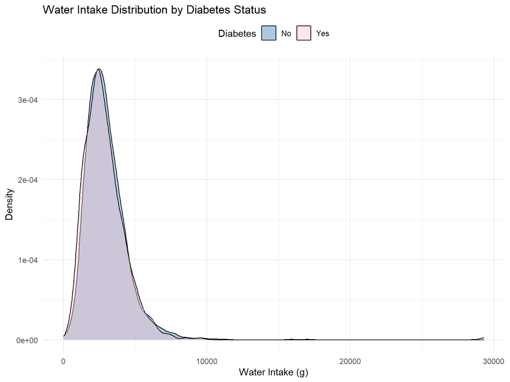

```r
p1 <- ggplot(df, aes(x = Water_g, fill = Diabetes)) +
  geom_density(alpha = 0.4) +
  scale_fill_manual(values = c("No" = "#2c7bb6", "Yes" = "pink")) +
  labs(title = "Water Intake Distribution by Diabetes Status",
       x = "Water Intake (g)", y = "Density", fill = "Diabetes") +
  theme_minimal() +
  theme(legend.position = "top")
print(p1)
```

```r
ggsave("figures/fig1_water_distribution.png", p1, width = 8, height = 6, dpi = 300)
```

# Figure 2: BMI distribution by water quartiles

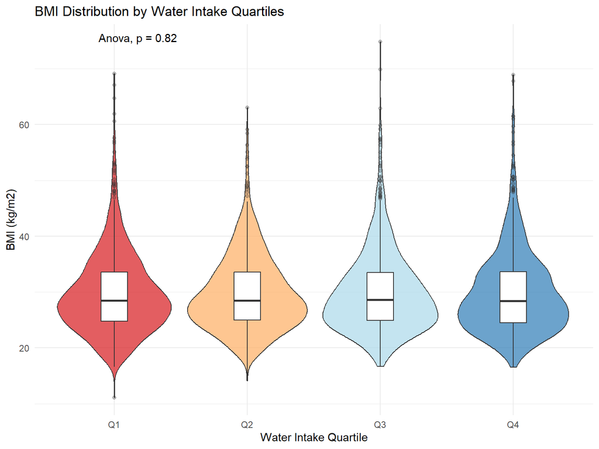

```r
p2 <- ggplot(df, aes(x = Water_Q, y = BMI, fill = Water_Q)) +
  geom_violin(alpha = 0.7) +
  geom_boxplot(width = 0.2, fill = "white", outlier.alpha = 0.3) +
  stat_compare_means(method = "anova") +
  scale_fill_manual(values = c("#d7191c", "#fdae61", "#abd9e9", "#2c7bb6")) +
  labs(title = "BMI Distribution by Water Intake Quartiles",
       x = "Water Intake Quartile", y = "BMI (kg/m2)") +
  theme_minimal() +
  theme(legend.position = "none")
print(p2)
```

```r
ggsave("figures/fig2_bmi_quartiles.png", p2, width = 8, height = 6, dpi = 300)
```

# Figure 3: Water intake vs HbA1c by diabetes status

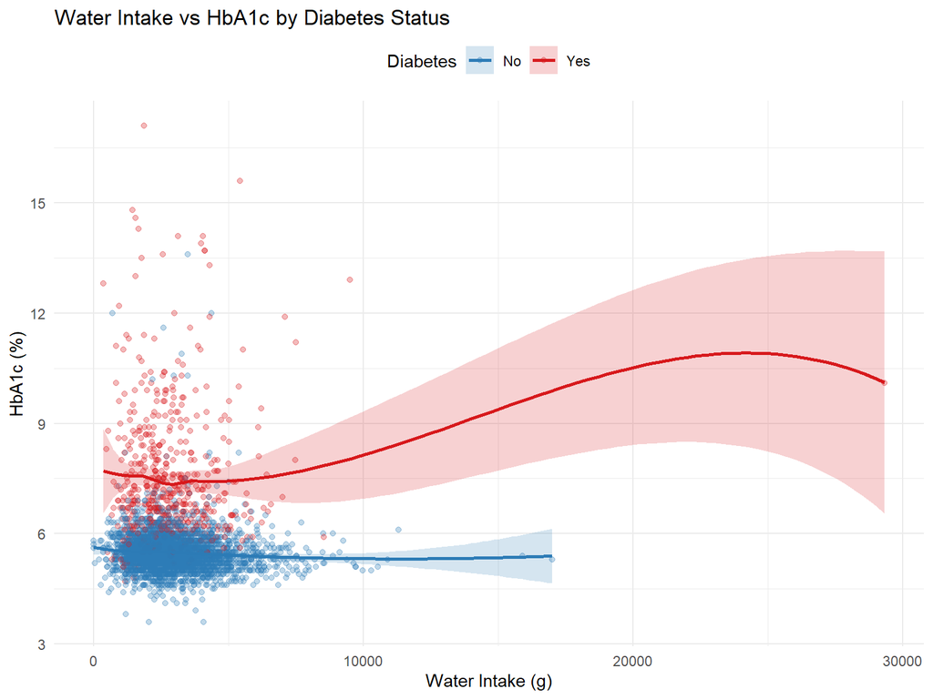

```r
p3 <- ggplot(df, aes(x = Water_g, y = HbA1c, color = Diabetes, fill = Diabetes)) +
  geom_point(alpha = 0.3, size = 1.5) +
  geom_smooth(method = "loess", alpha = 0.2) +
  scale_color_manual(values = c("No" = "#2c7bb6", "Yes" = "#d7191c")) +
  scale_fill_manual(values = c("No" = "#2c7bb6", "Yes" = "#d7191c")) +
  labs(title = "Water Intake vs HbA1c by Diabetes Status",
       x = "Water Intake (g)", y = "HbA1c (%)",
       color = "Diabetes", fill = "Diabetes") +
  theme_minimal() +
  theme(legend.position = "top")
print(p3)
```

```r
ggsave("figures/fig3_water_hba1c.png", p3, width = 8, height = 6, dpi = 300)
```

# Figure 4: Forest plot - OR by quartiles (FIXED)

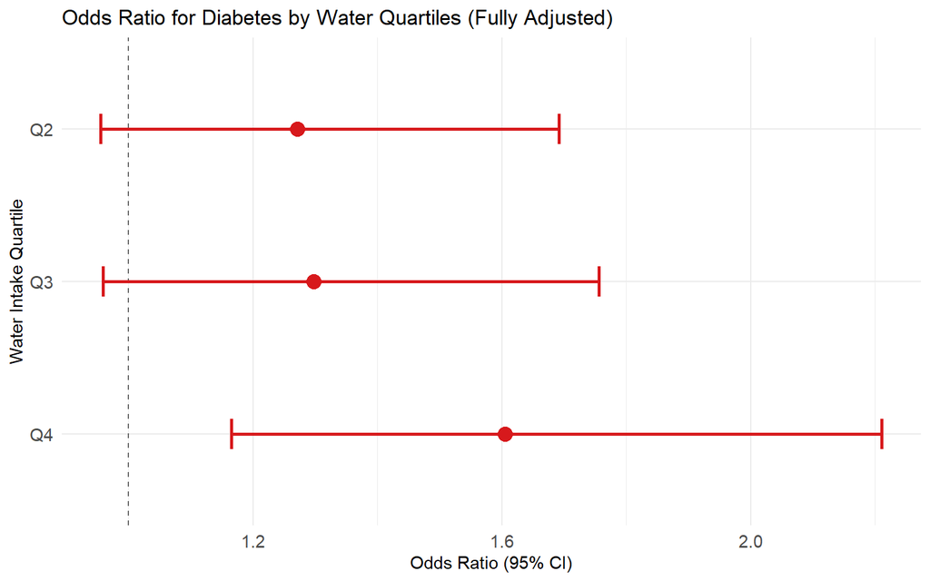

```r
# Only keep rows where Quartile is Q2, Q3, Q4 AND belongs to Fully Adjusted model
or_plot <- or_results %>%
  mutate(row_id = row_number()) %>%
  filter(Quartile %in% c("Q2", "Q3", "Q4")) %>%
  # Find which rows belong to Fully Adjusted section
  mutate(in_fully_adjusted = FALSE)

# Manually identify Fully Adjusted section
fully_adj_start <- which(or_results$Model == "Fully Adjusted")
if(length(fully_adj_start) > 0) {
  # Get all rows from Fully Adjusted start until next model or end
  next_model <- which(or_results$Model != "" & or_results$Model != "Fully Adjusted")
  next_model <- next_model[next_model > fully_adj_start]

  if(length(next_model) > 0) {
    fully_adj_end <- next_model[1] - 1
  } else {
    fully_adj_end <- nrow(or_results)
  }

  or_plot <- or_results %>%
    slice(fully_adj_start:fully_adj_end) %>%
    filter(Quartile != "Q1 (Ref)")
}

# Create plot
p4 <- ggplot(or_plot, aes(x = OR, y = factor(Quartile, levels = c("Q4", "Q3", "Q2")))) +
  geom_vline(xintercept = 1, linetype = "dashed", color = "gray40") +
  geom_point(size = 4, color = "#d7191c") +
  geom_errorbarh(aes(xmin = Lower, xmax = Upper),
                 height = 0.2, color = "#d7191c", linewidth = 1) +
  labs(title = "Odds Ratio for Diabetes by Water Quartiles (Fully Adjusted)",
       x = "Odds Ratio (95% CI)", y = "Water Intake Quartile") +
  theme_minimal() +
  theme(axis.text = element_text(size = 11))
print(p4)
```

```r
ggsave("figures/fig4_odds_ratio.png", p4, width = 8, height = 5, dpi = 300)
```

# Figure 5: Forest plot - Beta by quartiles (FIXED)

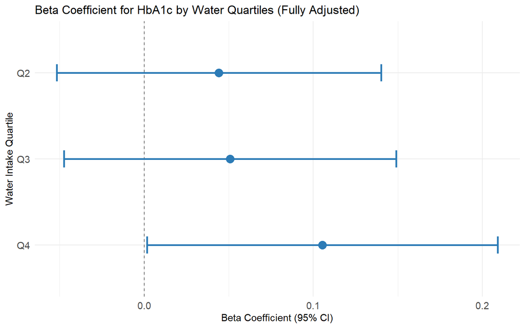

```r
# Same logic for beta
fully_adj_start <- which(beta_results$Model == "Fully Adjusted")
if(length(fully_adj_start) > 0) {
  next_model <- which(beta_results$Model != "" & beta_results$Model != "Fully Adjusted")
  next_model <- next_model[next_model > fully_adj_start]

  if(length(next_model) > 0) {
    fully_adj_end <- next_model[1] - 1
  } else {
    fully_adj_end <- nrow(beta_results)
  }

  beta_plot <- beta_results %>%
    slice(fully_adj_start:fully_adj_end) %>%
    filter(Quartile != "Q1 (Ref)")
}

# Create plot
p5 <- ggplot(beta_plot, aes(x = Beta, y = factor(Quartile, levels = c("Q4", "Q3", "Q2")))) +
  geom_vline(xintercept = 0, linetype = "dashed", color = "gray40") +
  geom_point(size = 4, color = "#2c7bb6") +
  geom_errorbarh(aes(xmin = Lower, xmax = Upper),
                 height = 0.2, color = "#2c7bb6", linewidth = 1) +
  labs(title = "Beta Coefficient for HbA1c by Water Quartiles (Fully Adjusted)",
       x = "Beta Coefficient (95% CI)", y = "Water Intake Quartile") +
  theme_minimal() +
  theme(axis.text = element_text(size = 11))
print(p5)
```

```r
ggsave("figures/fig5_beta_coefficient.png", p5, width = 8, height = 5, dpi = 300)
```

# Figure 7: Mean HbA1c by quartiles

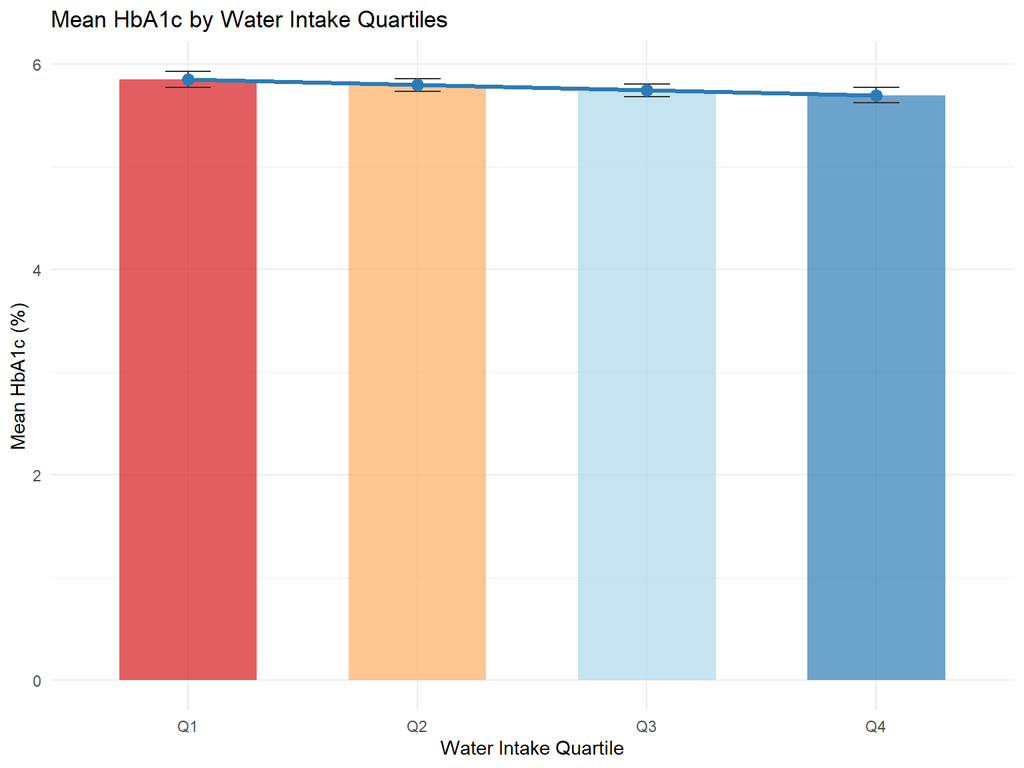

```r
# Prepare data
trend_hba1c <- df %>%
  group_by(Water_Q) %>%
  summarise(
    mean = mean(HbA1c, na.rm = TRUE),
    sd = sd(HbA1c, na.rm = TRUE),
    n = n(),
    .groups = 'drop'
  ) %>%
  mutate(se = sd / sqrt(n))

# Create plot
p7 <- ggplot(trend_hba1c, aes(x = Water_Q, y = mean, group = 1)) +
  geom_col(aes(fill = Water_Q), alpha = 0.7, width = 0.6) +
  geom_errorbar(aes(ymin = mean - 1.96*se, ymax = mean + 1.96*se),
                width = 0.2, color = "gray20") +
  geom_line(color = "#2c7bb6", linewidth = 1.2) +
  geom_point(color = "#2c7bb6", size = 3) +
  scale_fill_manual(values = c("#d7191c", "#fdae61", "#abd9e9", "#2c7bb6")) +
  labs(title = "Mean HbA1c by Water Intake Quartiles",
       x = "Water Intake Quartile", y = "Mean HbA1c (%)") +
  theme_minimal() +
  theme(legend.position = "none")
print(p7)
```

```r
ggsave("figures/fig7_hba1c_mean.png", p7, width = 8, height = 6, dpi = 300)
```

# Figure 8: Correlation heatmap

```r
# Prepare data
cor_data <- df %>%
  select(Water_g, Age, BMI, Energy_kcal, Sugar_g, HbA1c) %>%
  drop_na()

# Create and save plot
png("figures/fig8_correlation.png", width = 2400, height = 2400, res = 300)
corrplot(cor(cor_data),
         method = "color",
         type = "upper",
         addCoef.col = "black",
         number.cex = 0.8,
         tl.col = "black",
         tl.srt = 45,
         col = colorRampPalette(c("#2c7bb6", "white", "pink"))(200))
dev.off()
```

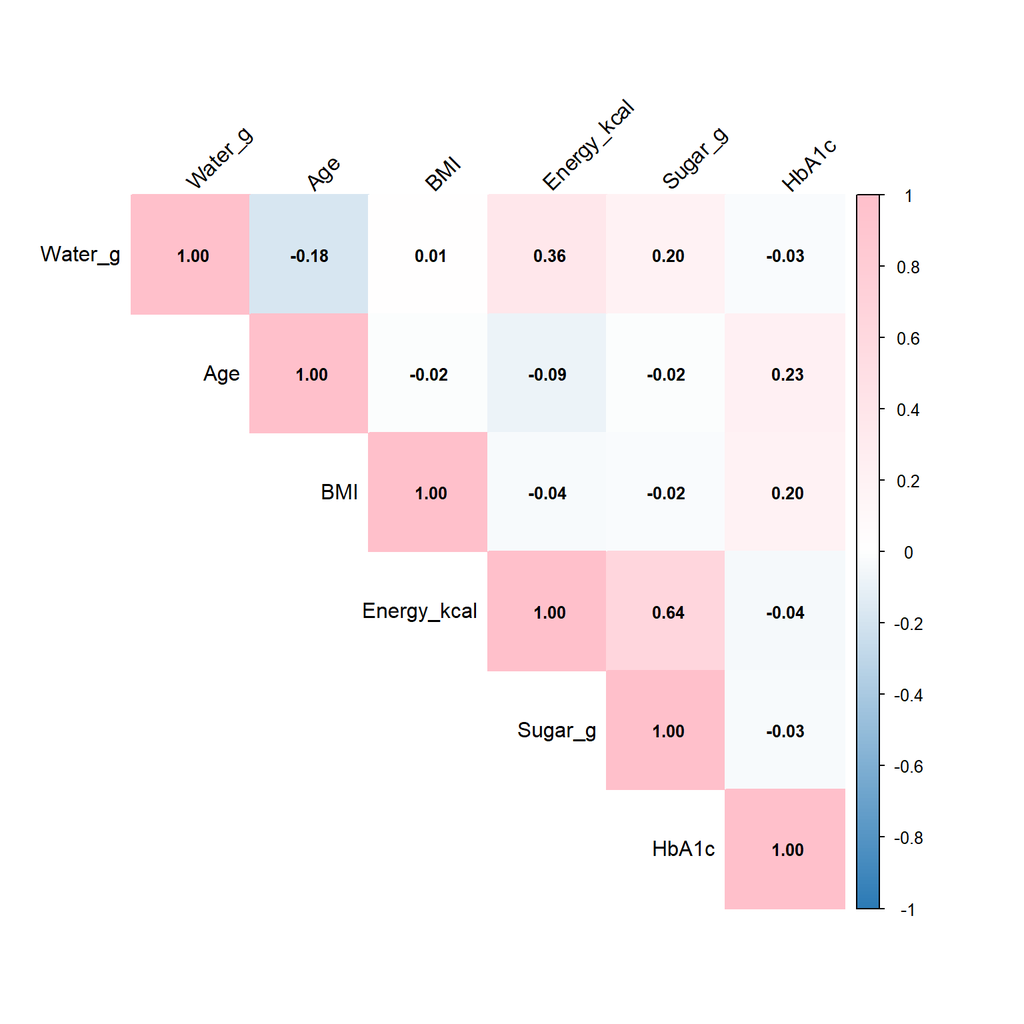

```r
# Display in notebook
corrplot(cor(cor_data),
         method = "color",
         type = "upper",
         addCoef.col = "black",
         number.cex = 0.8,
         tl.col = "black",
         tl.srt = 45,
         col = colorRampPalette(c("#2c7bb6", "white", "pink"))(200))
```

# Figure 9: Stratified by BMI

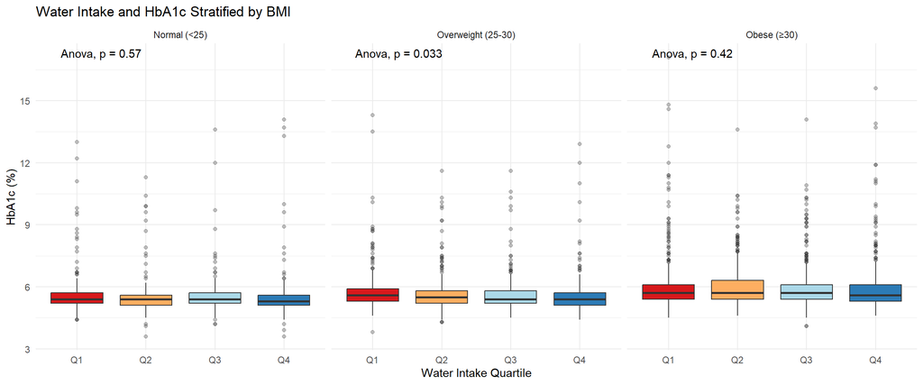

```r
# Prepare data
df_plot <- df %>%
  mutate(BMI_cat = cut(BMI,
                       breaks = c(0, 25, 30, Inf),
                       labels = c("Normal (<25)", "Overweight (25-30)", "Obese (≥30)"))) %>%
  filter(!is.na(BMI_cat))

# Create plot
p9 <- ggplot(df_plot, aes(x = Water_Q, y = HbA1c, fill = Water_Q)) +
  geom_boxplot(outlier.alpha = 0.3) +
  facet_wrap(~BMI_cat, nrow = 1) +
  stat_compare_means(method = "anova") +
  scale_fill_manual(values = c("#d7191c", "#fdae61", "#abd9e9", "#2c7bb6")) +
  labs(title = "Water Intake and HbA1c Stratified by BMI",
       x = "Water Intake Quartile", y = "HbA1c (%)") +
  theme_minimal() +
  theme(legend.position = "none")
print(p9)
```

```r
ggsave("figures/fig9_stratified_bmi.png", p9, width = 12, height = 5, dpi = 300)
```